# examples_0324

A cubic polynomial, $f(x)$, is generated by randomly selecting the three parameters, $B$, $C$, and $D$, in the equation below.

$$f(x)~=~x^3+Bx^2+Cx+D$$

You know the graph $y=f(x)$ has three distinct real roots at $x=-6$, $x=-2$, and $x=4$, as shown below.

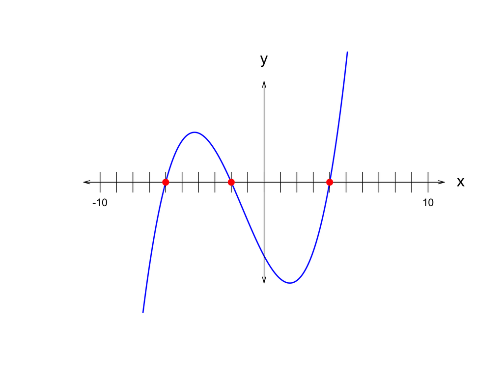

Find $B$, $C$, and $D$.

- $B=$
- $C=$
- $D=$

First, write the cubic polynomial in factored form (based on the three roots).

$$f(x)~=~(x+{6})(x+{2})(x-{4})$$

Partially expand the expression by writing $(x+{6})(x+{2})$ in standard form. To do this, we can use the FOIL method or a box.

| * | $x$ | $6$ |
| --- | --- | --- |
| $x$ | $x^2$ | $6x$ |
| $2$ | $2x$ | $12$ |

$$f(x)~=~
\left(x^{2}+{2}x+{6}x+{12}\right)(x-{4})$$

Combine like terms.

$$f(x)~=~
\left(x^{2}+{8}x+{12}\right)(x-{4})$$

Now, multiply the quadratic by the linear.

| * | $x^2$ | $8x$ | $12$ |
| --- | --- | --- | --- |
| $x$ | $x^3$ | $8x^2$ | $12x$ |
| $-4$ | $-4x^2$ | $-32x$ | $-48$ |

$$f(x)~=~x^{3}-{4}x^{2}+{8}x^{2}-{32}x+{12}x-{48}$$

Combine like terms.

$$f(x)~=~x^{3}+{4}x^{2}-{20}x-{48}$$

Thus,

- $B=4$
- $C=-20$
- $D=-48$

A cubic polynomial, $f(x)$, is generated by randomly selecting the three parameters, $B$, $C$, and $D$, in the equation below.

$$f(x)~=~x^3+Bx^2+Cx+D$$

You know the graph $y=f(x)$ has three distinct real roots at $x=-5$, $x=-3$, and $x=-1$, as shown below.

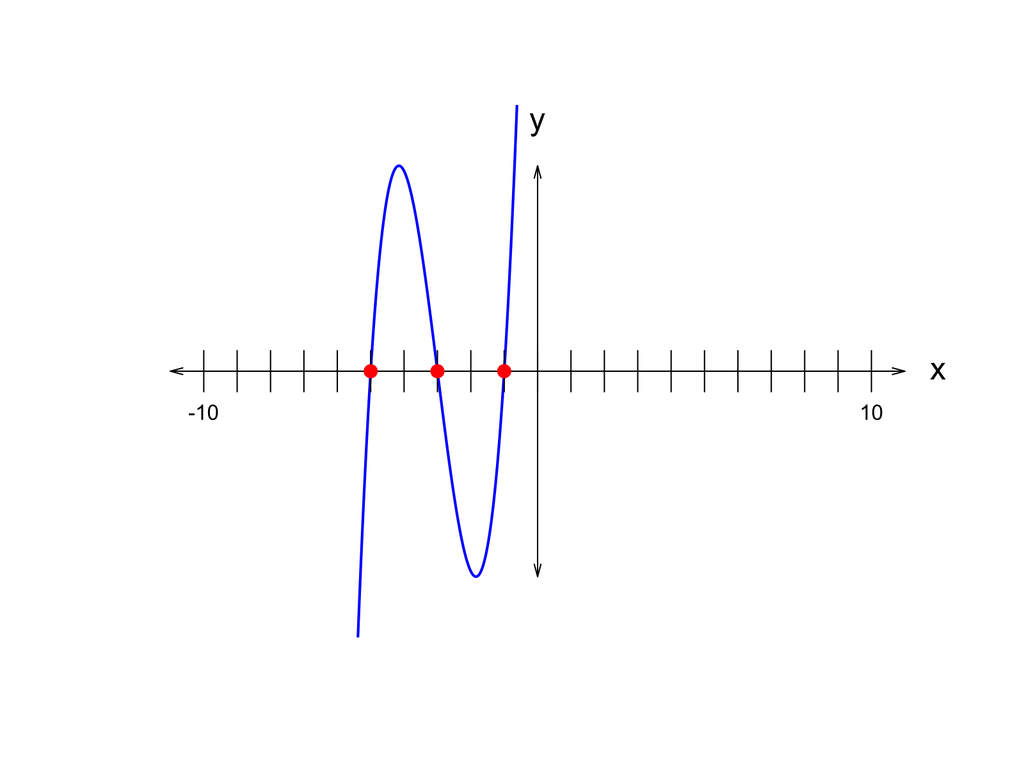

Find $B$, $C$, and $D$.

- $B=$
- $C=$
- $D=$

First, write the cubic polynomial in factored form (based on the three roots).

$$f(x)~=~(x+{5})(x+{3})(x+{1})$$

Partially expand the expression by writing $(x+{5})(x+{3})$ in standard form. To do this, we can use the FOIL method or a box.

| * | $x$ | $5$ |
| --- | --- | --- |
| $x$ | $x^2$ | $5x$ |
| $3$ | $3x$ | $15$ |

$$f(x)~=~
\left(x^{2}+{3}x+{5}x+{15}\right)(x+{1})$$

Combine like terms.

$$f(x)~=~
\left(x^{2}+{8}x+{15}\right)(x+{1})$$

Now, multiply the quadratic by the linear.

| * | $x^2$ | $8x$ | $15$ |
| --- | --- | --- | --- |
| $x$ | $x^3$ | $8x^2$ | $15x$ |
| $1$ | $1x^2$ | $8x$ | $15$ |

$$f(x)~=~x^{3}+x^{2}+{8}x^{2}+{8}x+{15}x+{15}$$

Combine like terms.

$$f(x)~=~x^{3}+{9}x^{2}+{23}x+{15}$$

Thus,

- $B=9$
- $C=23$
- $D=15$

A cubic polynomial, $f(x)$, is generated by randomly selecting the three parameters, $B$, $C$, and $D$, in the equation below.

$$f(x)~=~x^3+Bx^2+Cx+D$$

You know the graph $y=f(x)$ has three distinct real roots at $x=-4$, $x=-3$, and $x=-2$, as shown below.

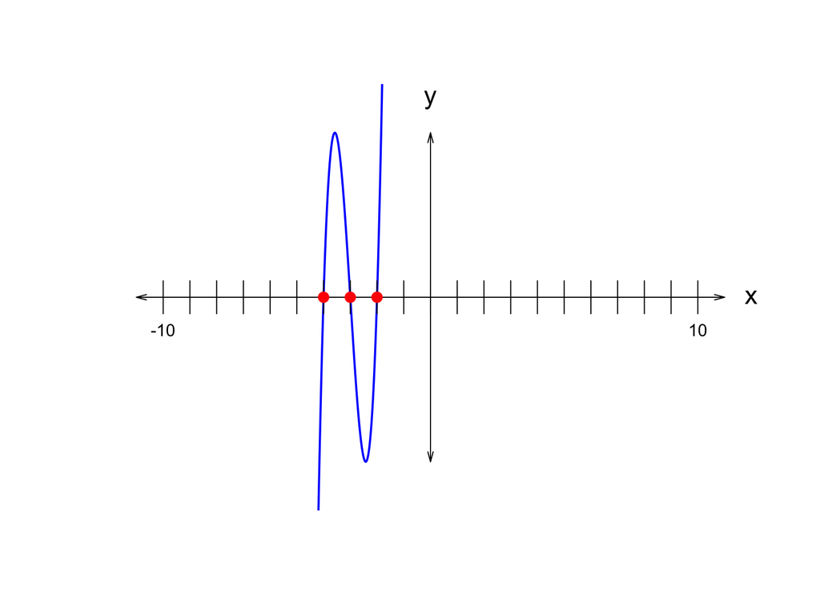

Find $B$, $C$, and $D$.

- $B=$
- $C=$
- $D=$

First, write the cubic polynomial in factored form (based on the three roots).

$$f(x)~=~(x+{4})(x+{3})(x+{2})$$

Partially expand the expression by writing $(x+{4})(x+{3})$ in standard form. To do this, we can use the FOIL method or a box.

| * | $x$ | $4$ |
| --- | --- | --- |
| $x$ | $x^2$ | $4x$ |
| $3$ | $3x$ | $12$ |

$$f(x)~=~
\left(x^{2}+{3}x+{4}x+{12}\right)(x+{2})$$

Combine like terms.

$$f(x)~=~
\left(x^{2}+{7}x+{12}\right)(x+{2})$$

Now, multiply the quadratic by the linear.

| * | $x^2$ | $7x$ | $12$ |
| --- | --- | --- | --- |
| $x$ | $x^3$ | $7x^2$ | $12x$ |
| $2$ | $2x^2$ | $14x$ | $24$ |

$$f(x)~=~x^{3}+{2}x^{2}+{7}x^{2}+{14}x+{12}x+{24}$$

Combine like terms.

$$f(x)~=~x^{3}+{9}x^{2}+{26}x+{24}$$

Thus,

- $B=9$
- $C=26$
- $D=24$

A cubic polynomial, $f(x)$, is generated by randomly selecting the three parameters, $B$, $C$, and $D$, in the equation below.

$$f(x)~=~x^3+Bx^2+Cx+D$$

You know the graph $y=f(x)$ has three distinct real roots at $x=-3$, $x=-1$, and $x=1$, as shown below.

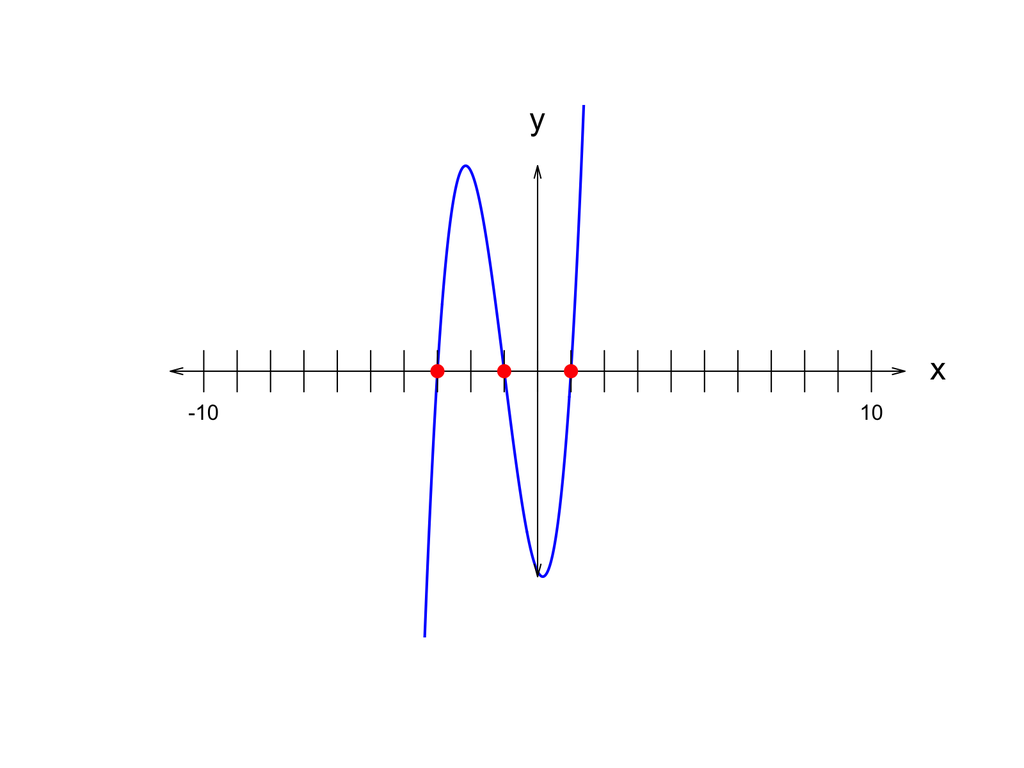

Find $B$, $C$, and $D$.

- $B=$
- $C=$
- $D=$

First, write the cubic polynomial in factored form (based on the three roots).

$$f(x)~=~(x+{3})(x+{1})(x-{1})$$

Partially expand the expression by writing $(x+{3})(x+{1})$ in standard form. To do this, we can use the FOIL method or a box.

| * | $x$ | $3$ |
| --- | --- | --- |
| $x$ | $x^2$ | $3x$ |
| $1$ | $1x$ | $3$ |

$$f(x)~=~
\left(x^{2}+x+{3}x+{3}\right)(x-{1})$$

Combine like terms.

$$f(x)~=~
\left(x^{2}+{4}x+{3}\right)(x-{1})$$

Now, multiply the quadratic by the linear.

| * | $x^2$ | $4x$ | $3$ |
| --- | --- | --- | --- |
| $x$ | $x^3$ | $4x^2$ | $3x$ |
| $-1$ | $-1x^2$ | $-4x$ | $-3$ |

$$f(x)~=~x^{3}-x^{2}+{4}x^{2}-{4}x+{3}x-{3}$$

Combine like terms.

$$f(x)~=~x^{3}+{3}x^{2}-x-{3}$$

Thus,

- $B=3$
- $C=-1$
- $D=-3$

A cubic polynomial, $f(x)$, is generated by randomly selecting the three parameters, $B$, $C$, and $D$, in the equation below.

$$f(x)~=~x^3+Bx^2+Cx+D$$

You know the graph $y=f(x)$ has three distinct real roots at $x=-6$, $x=-3$, and $x=4$, as shown below.

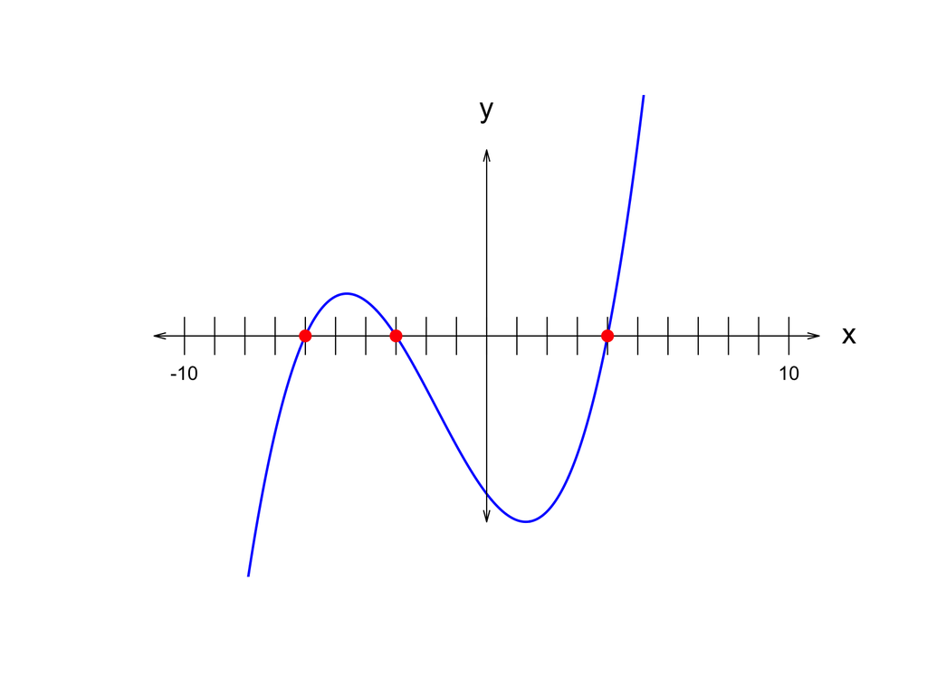

Find $B$, $C$, and $D$.

- $B=$
- $C=$
- $D=$

First, write the cubic polynomial in factored form (based on the three roots).

$$f(x)~=~(x+{6})(x+{3})(x-{4})$$

Partially expand the expression by writing $(x+{6})(x+{3})$ in standard form. To do this, we can use the FOIL method or a box.

| * | $x$ | $6$ |
| --- | --- | --- |
| $x$ | $x^2$ | $6x$ |
| $3$ | $3x$ | $18$ |

$$f(x)~=~
\left(x^{2}+{3}x+{6}x+{18}\right)(x-{4})$$

Combine like terms.

$$f(x)~=~
\left(x^{2}+{9}x+{18}\right)(x-{4})$$

Now, multiply the quadratic by the linear.

| * | $x^2$ | $9x$ | $18$ |
| --- | --- | --- | --- |
| $x$ | $x^3$ | $9x^2$ | $18x$ |
| $-4$ | $-4x^2$ | $-36x$ | $-72$ |

$$f(x)~=~x^{3}-{4}x^{2}+{9}x^{2}-{36}x+{18}x-{72}$$

Combine like terms.

$$f(x)~=~x^{3}+{5}x^{2}-{18}x-{72}$$

Thus,

- $B=5$
- $C=-18$
- $D=-72$

A cubic polynomial, $f(x)$, is generated by randomly selecting the three parameters, $B$, $C$, and $D$, in the equation below.

$$f(x)~=~x^3+Bx^2+Cx+D$$

You know the graph $y=f(x)$ has three distinct real roots at $x=-3$, $x=-2$, and $x=5$, as shown below.

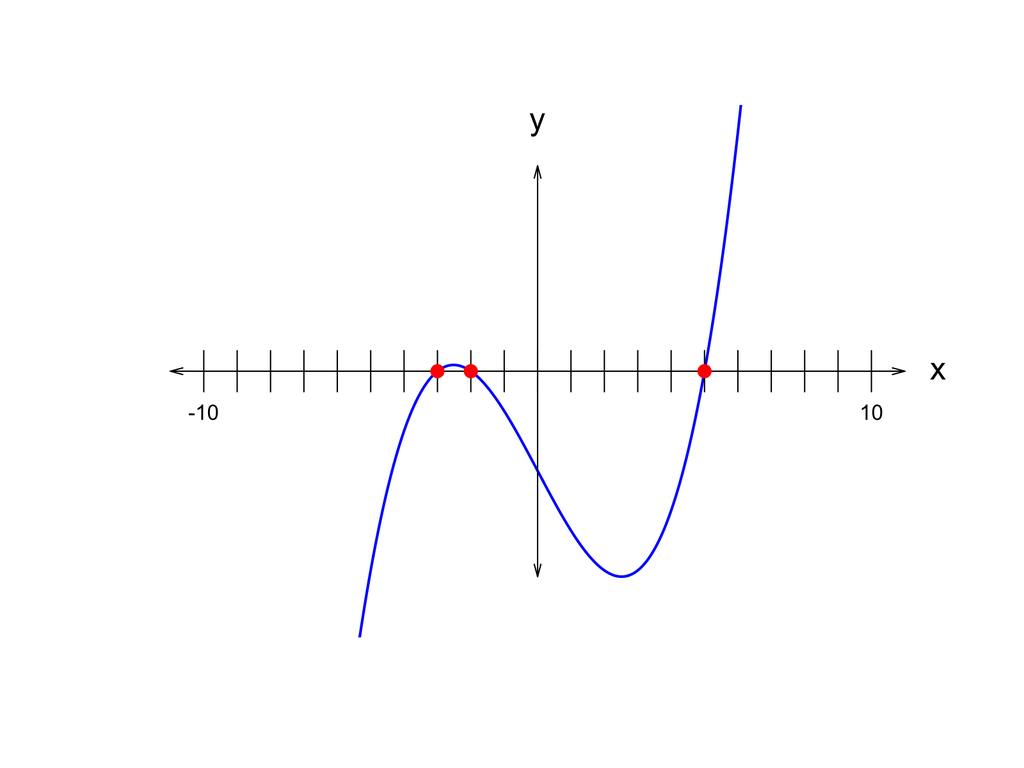

Find $B$, $C$, and $D$.

- $B=$
- $C=$
- $D=$

First, write the cubic polynomial in factored form (based on the three roots).

$$f(x)~=~(x+{3})(x+{2})(x-{5})$$

Partially expand the expression by writing $(x+{3})(x+{2})$ in standard form. To do this, we can use the FOIL method or a box.

| * | $x$ | $3$ |
| --- | --- | --- |
| $x$ | $x^2$ | $3x$ |
| $2$ | $2x$ | $6$ |

$$f(x)~=~
\left(x^{2}+{2}x+{3}x+{6}\right)(x-{5})$$

Combine like terms.

$$f(x)~=~
\left(x^{2}+{5}x+{6}\right)(x-{5})$$

Now, multiply the quadratic by the linear.

| * | $x^2$ | $5x$ | $6$ |
| --- | --- | --- | --- |
| $x$ | $x^3$ | $5x^2$ | $6x$ |
| $-5$ | $-5x^2$ | $-25x$ | $-30$ |

$$f(x)~=~x^{3}-{5}x^{2}+{5}x^{2}-{25}x+{6}x-{30}$$

Combine like terms.

$$f(x)~=~x^{3}-{19}x-{30}$$

Thus,

- $B=0$
- $C=-19$
- $D=-30$

A cubic polynomial, $f(x)$, is generated by randomly selecting the three parameters, $B$, $C$, and $D$, in the equation below.

$$f(x)~=~x^3+Bx^2+Cx+D$$

You know the graph $y=f(x)$ has three distinct real roots at $x=-3$, $x=2$, and $x=5$, as shown below.

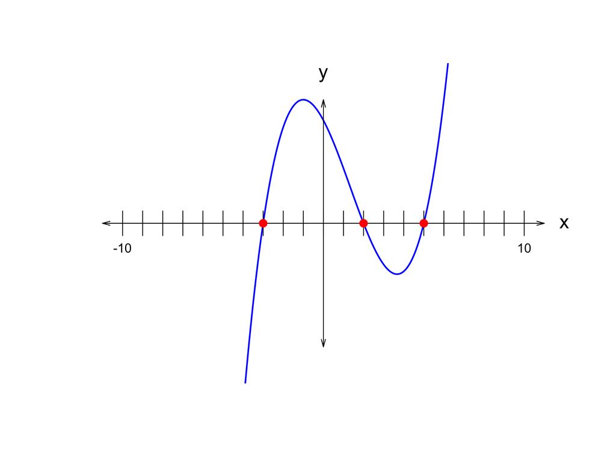

Find $B$, $C$, and $D$.

- $B=$
- $C=$
- $D=$

First, write the cubic polynomial in factored form (based on the three roots).

$$f(x)~=~(x+{3})(x-{2})(x-{5})$$

Partially expand the expression by writing $(x+{3})(x-{2})$ in standard form. To do this, we can use the FOIL method or a box.

| * | $x$ | $3$ |
| --- | --- | --- |
| $x$ | $x^2$ | $3x$ |
| $-2$ | $-2x$ | $-6$ |

$$f(x)~=~
\left(x^{2}-{2}x+{3}x-{6}\right)(x-{5})$$

Combine like terms.

$$f(x)~=~
\left(x^{2}+x-{6}\right)(x-{5})$$

Now, multiply the quadratic by the linear.

| * | $x^2$ | $1x$ | $-6$ |
| --- | --- | --- | --- |
| $x$ | $x^3$ | $1x^2$ | $-6x$ |
| $-5$ | $-5x^2$ | $-5x$ | $30$ |

$$f(x)~=~x^{3}-{5}x^{2}+x^{2}-{5}x-{6}x+{30}$$

Combine like terms.

$$f(x)~=~x^{3}-{4}x^{2}-{11}x+{30}$$

Thus,

- $B=-4$
- $C=-11$
- $D=30$

A cubic polynomial, $f(x)$, is generated by randomly selecting the three parameters, $B$, $C$, and $D$, in the equation below.

$$f(x)~=~x^3+Bx^2+Cx+D$$

You know the graph $y=f(x)$ has three distinct real roots at $x=-6$, $x=-2$, and $x=-1$, as shown below.

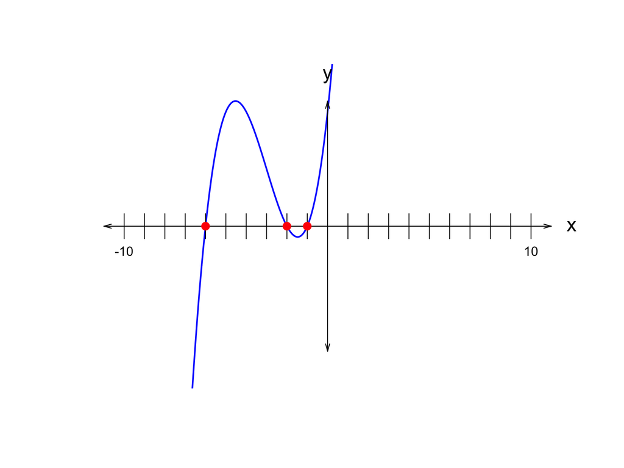

Find $B$, $C$, and $D$.

- $B=$
- $C=$
- $D=$

First, write the cubic polynomial in factored form (based on the three roots).

$$f(x)~=~(x+{6})(x+{2})(x+{1})$$

Partially expand the expression by writing $(x+{6})(x+{2})$ in standard form. To do this, we can use the FOIL method or a box.

| * | $x$ | $6$ |
| --- | --- | --- |
| $x$ | $x^2$ | $6x$ |
| $2$ | $2x$ | $12$ |

$$f(x)~=~
\left(x^{2}+{2}x+{6}x+{12}\right)(x+{1})$$

Combine like terms.

$$f(x)~=~
\left(x^{2}+{8}x+{12}\right)(x+{1})$$

Now, multiply the quadratic by the linear.

| * | $x^2$ | $8x$ | $12$ |
| --- | --- | --- | --- |
| $x$ | $x^3$ | $8x^2$ | $12x$ |
| $1$ | $1x^2$ | $8x$ | $12$ |

$$f(x)~=~x^{3}+x^{2}+{8}x^{2}+{8}x+{12}x+{12}$$

Combine like terms.

$$f(x)~=~x^{3}+{9}x^{2}+{20}x+{12}$$

Thus,

- $B=9$
- $C=20$
- $D=12$

A cubic polynomial, $f(x)$, is generated by randomly selecting the three parameters, $B$, $C$, and $D$, in the equation below.

$$f(x)~=~x^3+Bx^2+Cx+D$$

You know the graph $y=f(x)$ has three distinct real roots at $x=3$, $x=4$, and $x=5$, as shown below.

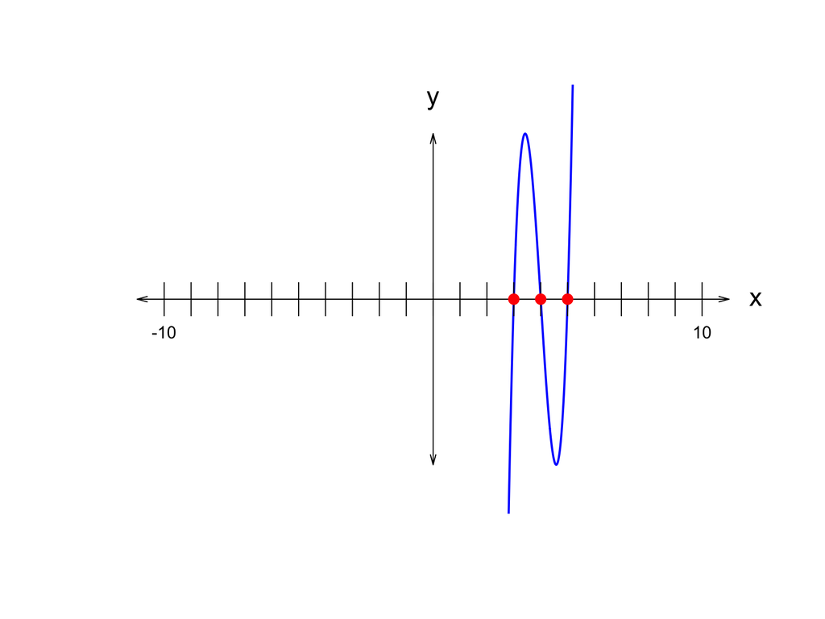

Find $B$, $C$, and $D$.

- $B=$
- $C=$
- $D=$

First, write the cubic polynomial in factored form (based on the three roots).

$$f(x)~=~(x-{3})(x-{4})(x-{5})$$

Partially expand the expression by writing $(x-{3})(x-{4})$ in standard form. To do this, we can use the FOIL method or a box.

| * | $x$ | $-3$ |
| --- | --- | --- |
| $x$ | $x^2$ | $-3x$ |
| $-4$ | $-4x$ | $12$ |

$$f(x)~=~
\left(x^{2}-{4}x-{3}x+{12}\right)(x-{5})$$

Combine like terms.

$$f(x)~=~
\left(x^{2}-{7}x+{12}\right)(x-{5})$$

Now, multiply the quadratic by the linear.

| * | $x^2$ | $-7x$ | $12$ |
| --- | --- | --- | --- |
| $x$ | $x^3$ | $-7x^2$ | $12x$ |
| $-5$ | $-5x^2$ | $35x$ | $-60$ |

$$f(x)~=~x^{3}-{5}x^{2}-{7}x^{2}+{35}x+{12}x-{60}$$

Combine like terms.

$$f(x)~=~x^{3}-{12}x^{2}+{47}x-{60}$$

Thus,

- $B=-12$
- $C=47$
- $D=-60$

A cubic polynomial, $f(x)$, is generated by randomly selecting the three parameters, $B$, $C$, and $D$, in the equation below.

$$f(x)~=~x^3+Bx^2+Cx+D$$

You know the graph $y=f(x)$ has three distinct real roots at $x=-6$, $x=-2$, and $x=1$, as shown below.

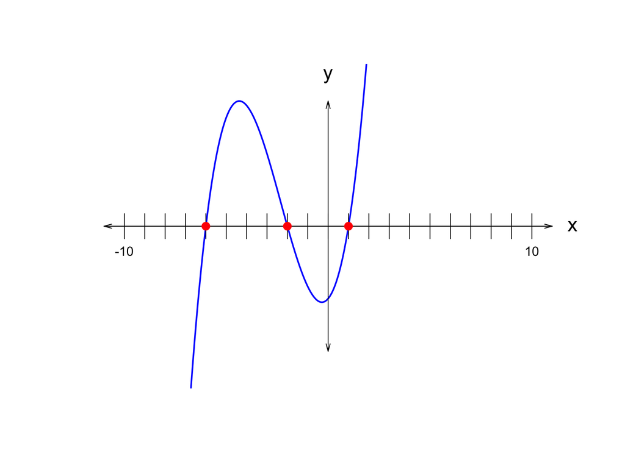

Find $B$, $C$, and $D$.

- $B=$
- $C=$
- $D=$

First, write the cubic polynomial in factored form (based on the three roots).

$$f(x)~=~(x+{6})(x+{2})(x-{1})$$

Partially expand the expression by writing $(x+{6})(x+{2})$ in standard form. To do this, we can use the FOIL method or a box.

| * | $x$ | $6$ |
| --- | --- | --- |
| $x$ | $x^2$ | $6x$ |
| $2$ | $2x$ | $12$ |

$$f(x)~=~
\left(x^{2}+{2}x+{6}x+{12}\right)(x-{1})$$

Combine like terms.

$$f(x)~=~
\left(x^{2}+{8}x+{12}\right)(x-{1})$$

Now, multiply the quadratic by the linear.

| * | $x^2$ | $8x$ | $12$ |
| --- | --- | --- | --- |
| $x$ | $x^3$ | $8x^2$ | $12x$ |
| $-1$ | $-1x^2$ | $-8x$ | $-12$ |

$$f(x)~=~x^{3}-x^{2}+{8}x^{2}-{8}x+{12}x-{12}$$

Combine like terms.

$$f(x)~=~x^{3}+{7}x^{2}+{4}x-{12}$$

Thus,

- $B=7$
- $C=4$
- $D=-12$